# Reproducible Research: Peer Assessment 1

This Assessment consists in a short analysis of a “quantified self dataset”.

This Assignment makes use of data from a personal activity monitoring device. The data consists of two months of data from an anonymous individual collected during the months of October and November, 2012 and include the number of steps taken in 5 minute intervals each day.

## Loading and preprocessing the data

The loading and preprocessing phase was performed using the following R code (note that activity.zip file is provided by the Assessment, and is a copy of the original file provided by the collector of the data).

```r
unzip('activity.zip')
activityData <- read.csv('activity.csv')
# converting date in the correct format
activityData$date <- as.Date(activityData$date)
```

This is how the imported data looks like:

```r
str(activityData)
```

```
## 'data.frame':    17568 obs. of  3 variables:
##  $ steps   : int  NA NA NA NA NA NA NA NA NA NA ...
##  $ date    : Date, format: "2012-10-01" "2012-10-01" ...
##  $ interval: int  0 5 10 15 20 25 30 35 40 45 ...
```

## Common utility functions

Two **utility functions** were created in order to simplify the generation of the figures for the analysis that was performed.

The following function was created to **plot an histogram of total steps per day**:

```r
plotTotalStepsPerDay <- function(data, title="Number of steps per Day") {
    stepsPerDay <- aggregate(data$steps,
                             by=list(date=data$date),
                             FUN=sum,  na.rm=TRUE)
    colnames(stepsPerDay) <- c('date','totalSteps')
    meanStepsPerDay <- mean(stepsPerDay$totalSteps)
    medianStepsPerDay <- median(stepsPerDay$totalSteps)
    # base plotting functions
    with(stepsPerDay, barplot(totalSteps, names.arg = date,
                              xlab="Day of measurement",
                              ylab="Total steps recorded",
                              main=title,
                              las=3, cex.names =.4, cex.axis=.8))
    abline(h=meanStepsPerDay, col="red", lty=2)
    abline(h=medianStepsPerDay, col="blue", lty=2)
    legend("topleft", col=c("red","blue"), lty=2,
           legend=c(paste("mean = ",round(meanStepsPerDay, digits=2)),
                    paste("median = ", medianStepsPerDay)),
           bg="transparent", cex=.8)
    return(data.frame(mean=meanStepsPerDay, median=medianStepsPerDay))
}
```

The following function was created to **plot a time series of average steps per 5-minute interval**:

```r
plotAvgIntervalStepsTimeSeries <- function(data, title="Average steps per 5-minute interval"){
    avgIntervalSteps <- aggregate(data$steps,
                                  by=list(interval=data$interval),
                                  FUN=mean,  na.rm=TRUE)
    colnames(avgIntervalSteps) <- c('interval','averageSteps')
    maxAvgSteps <- max(avgIntervalSteps$averageSteps)
    argmaxAvgSteps <- avgIntervalSteps[which.max(avgIntervalSteps$averageSteps),]$interval
    # base plotting functions
    with(avgIntervalSteps, plot(interval, averageSteps,
                                xlab="5-minute interval of measurement",
                                ylab="Average number of steps",
                                main=title,
                                type="l", las=3, cex.axis=.9))
    abline(v=argmaxAvgSteps, col="blue", lty=2)
    points(argmaxAvgSteps, maxAvgSteps, col="red", pch=8, lwd=2)
    legend("topright", col="red", pch=8, lwd=2, lty=NA,
           legend=paste("max = ", round(maxAvgSteps, digits=2)),
           bg="transparent", cex=.9)
    return(data.frame(argmax=argmaxAvgSteps, max=maxAvgSteps))
}
```

Both of these functions will be used in the following paragraphs to perform the Data Analysis.

## What is mean total number of steps taken per day?

An **histogram of total number of steps per day** was produced. Note that NA values in the dataset are removed by the utility function.

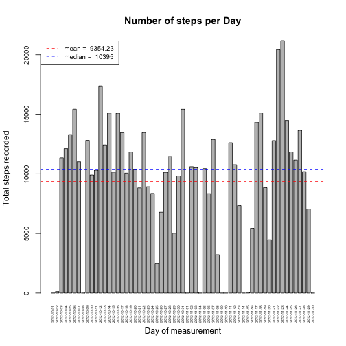

```r
totStepStat <- plotTotalStepsPerDay(activityData)
```

The average number of steps per day is *9354.2295 steps*, and the median number of steps per day is *10395 steps*.

## What is the average daily activity pattern?

By averaging over all days the 5-minute interval number of steps, a **time series of daily activity pattern** was produced.

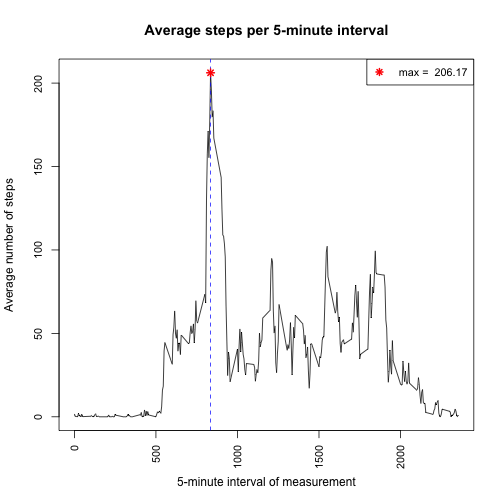

```r
avgStepStat <- plotAvgIntervalStepsTimeSeries(activityData)
```

The maximum average 5-minute interval number of steps is *206.1698 steps* and is reached at the *835° 5-minute interval* of the day.

## Imputing missing values

The above analysis was done by excluding the NA values from the dataset. The number of NA that are present for each column is:

```r
colSums(is.na(activityData))
```

```
##    steps     date interval
##     2304        0        0
```

The presence of NAs can add bias to the analysis. In order to **clean the NA values**, we decided to associate to each NA in the *steps* column of the data frame the average number of steps associated to its 5-minute interval (computed on the entire dataset). The average number of steps associated to NA values was also *rounded to the nearest greater integer value (ceiling)* in order to keep the steps variable as an integer value (a fractionary number of steps does not make physical sense).

The following code details transformation that was applied:

```r
avgStepsPerInterval <- aggregate(activityData$steps,
                                 by=list(interval=activityData$interval),
                                 FUN=mean,  na.rm=TRUE)
colnames(avgStepsPerInterval) <- c('interval','averageSteps')

cleanActivityData <- merge(x=activityData,
                           y=avgStepsPerInterval,
                           by="interval")

cleanActivityData$steps <- mapply(function(x,y) ifelse(is.na(x),
                                                       ceiling(y), x),
                                  cleanActivityData$steps,
                                  cleanActivityData$averageSteps)
# remove added column and unused datasets
cleanActivityData <- cleanActivityData[,-c(4)]
remove(avgStepsPerInterval)
```

The cleaned activity dataset can be now used to perform the same analysis performed on the original data set. In particular, the **histogram of total steps taken per day** becomes ad follows:

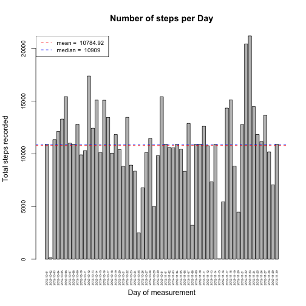

```r
totStepStatC <- plotTotalStepsPerDay(cleanActivityData)
```

Now, the average number of steps per day is 1.0785 × 10<sup>4</sup>, and the median number of steps per day is 1.0909 × 10<sup>4</sup>.

## Are there differences in activity patterns between weekdays and weekends?

In order to compare the different pattern of steps in weekDays and weekEnds, the (cleaned) activity data frame was **split into two distinct data frames, according to the day type (weekend or weekday)**:

```r
# NOTE: the following step probably requires English Locale
cleanActivityData$dayType <- as.factor(ifelse(weekdays(cleanActivityData$date) %in% c("Saturday", "Sunday"),"weekend","weekday"))

cleanWDActivityData <- subset(cleanActivityData,
                              dayType=="weekday",
                              select=c("interval","steps","date"))
cleanWEActivityData <- subset(cleanActivityData,
                              dayType=="weekend",
                              select=c("interval","steps","date"))
```

With these two datasets, a **comparative time series** was produced. One time series considers only weekdays and the other considers only weekends:

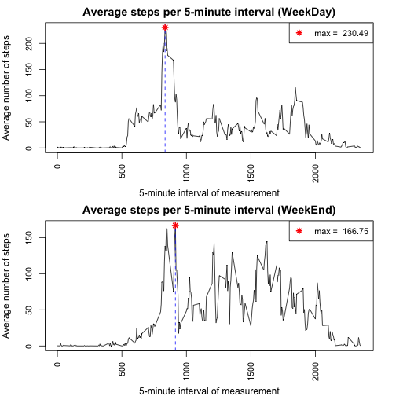

```r
par(mfrow=c(2,1))
par(mar=c(4,4,2,2))
avgWDStepStatC <- plotAvgIntervalStepsTimeSeries(cleanWDActivityData,
                    title="Average steps per 5-minute interval (WeekDay)")
avgWEStepStatC <- plotAvgIntervalStepsTimeSeries(cleanWEActivityData,
                    title="Average steps per 5-minute interval (WeekEnd)")
```

In weekdays, the maximum value of the average 5-minute interval number of steps is *230.4889 steps* and is reached at the *835° 5-minute interval* of the day.

In weekends, the maximum value of the average 5-minute interval number of steps is *166.75 steps* and is reached at the *915° 5-minute interval* of the day.